# Modeling autocorrelated data

Vojta Barták

2023-06-26

```r
library(tidyverse) # General metapackage for manipuating and visualizing data
library(sf)        # Vector spatial data manipulation and analysis
library(stars)     # Raster spatial data manipulation and analysis (compatible with sf)
library(tmap)      # Spatial data display
library(spdep)
library(SpatialPack)
library(gstat)     # Geostatistics
library(nlme)      # Generalized least squares
library(spaMM)
library(glmmTMB)
library(spatialreg)
library(mgcv)
library(mgcViz)
library(ranger)
library(spmoran)
library(car)
library(performance)
library(sjPlot)
```

## Data

### Reading and displaying the data

We’re gonna use data on monthly precipitation from meteorological stations in the Czech Republic, provided for free by the Czech Meteorological Institute. The data are from 2014, in the coordinate system routinely used in the region (S-JTSK Křovák, EPSG: 5514). We’re gonna focus on July precipitation values, stored in the column Jul.

```r
prec.sf <- st_read("data/precipitation_2014.shp") %>%
  st_transform(5514) %>%
  mutate(x = st_coordinates(.)[,1],
         y = st_coordinates(.)[,2]) %>%
  filter(!is.na(Jul))
summary(prec.sf$Jul)
```

```
##    Min. 1st Qu.  Median    Mean 3rd Qu.    Max.
##   1.065   2.543   3.274   3.387   4.045   8.444
```

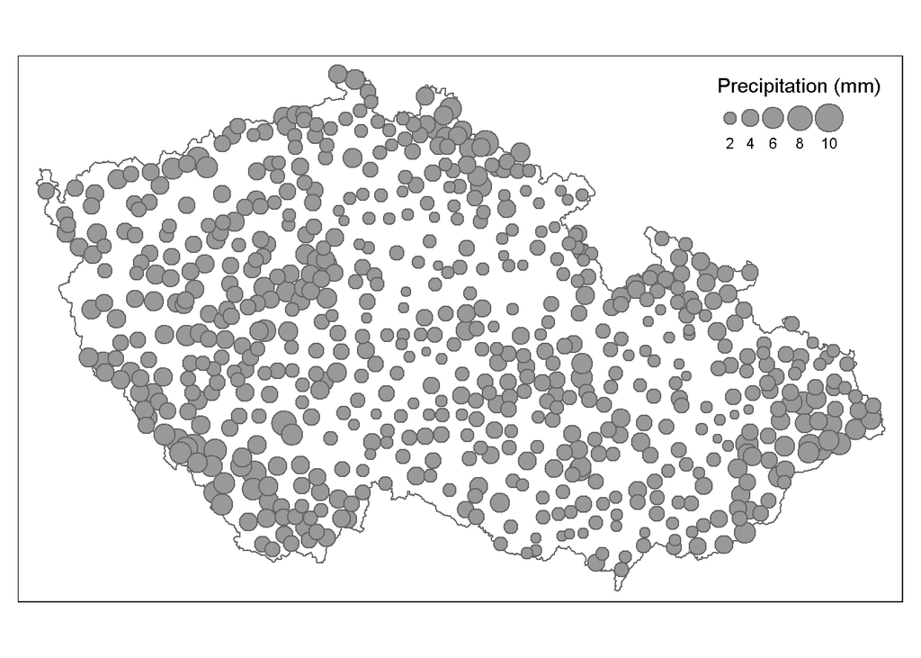

```r
regions <- st_read("data/kraje.shp")
tm_shape(regions %>% st_union) +
  tm_borders() +
  tm_shape(prec.sf) +
  tm_bubbles("Jul", title.size="Precipitation (mm)")
```

We’re also gonna use the elevation data at 1 km resolution. We’re gonna load the DTM raster into a stars object, which can be plotted using `tmap` together with `sf` vector data.

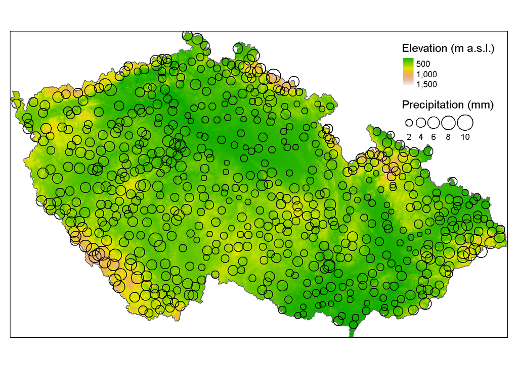

```r
dtm <- read_stars("data/dtm_CR_1000.tif")
tm_shape(dtm) +
  tm_raster(style="cont", palette = terrain.colors(12), title = "Elevation (m a.s.l.)") +
  tm_shape(regions %>% st_union) +
  tm_borders() +
  tm_shape(prec.sf) +
  tm_bubbles(size="Jul", alpha=0, border.col="black", title.size="Precipitation (mm)") +
  tm_layout(legend.position = c("right","top"))
```

### Examining the relationship with elevation

To examine the relationship of precipitation and elevation, we first need to extract the elevation values into the data points where we have the precipitation values. This can be done by the function `st_extract`, which takes a `stars` object (raster) and an `sf` object (points), and returns a new point `sf` object with the raster values stored in a first column. Because we need just this one column, we pull it out from the data frame (function `pull` from `dplyr`). We then store this column as a new column named “elev” in the `prec.sf` object.

We can then plot precipitation against elevation using `ggplot`.

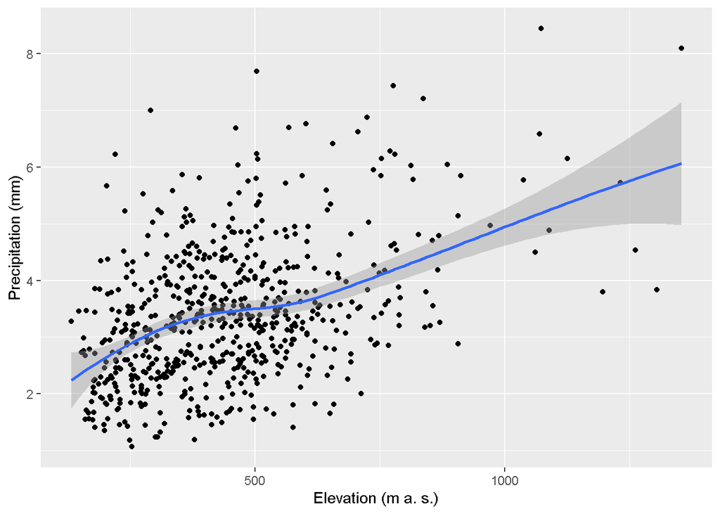

```r
prec.sf$elev <- st_extract(dtm, prec.sf) %>% pull(1)
ggplot(prec.sf, aes(x=elev, y=Jul)) +
  geom_point() +
  geom_smooth(se=T) +
  labs(x="Elevation (m a. s.)", y="Precipitation (mm)")
```

We see a clear, roughly linear relationship. To assess this relationship quantitatively, we can fit a linear model using ordinary least squares, i.e. so far ignoring the spatial autocorrelation.

```r
# linear model
mod.ols <- lm(Jul~elev, data=prec.sf)
summary(mod.ols)
```

```
##
## Call:
## lm(formula = Jul ~ elev, data = prec.sf)
##
## Residuals:
##     Min      1Q  Median      3Q     Max
## -2.3356 -0.7686 -0.0987  0.6294  4.1415
##
## Coefficients:
##              Estimate Std. Error t value Pr(>|t|)
## (Intercept) 2.1962987  0.1088095   20.18   <2e-16 ***
## elev        0.0026837  0.0002251   11.92   <2e-16 ***
## ---
## Signif. codes:  0 '***' 0.001 '**' 0.01 '*' 0.05 '.' 0.1 ' ' 1
##
## Residual standard error: 1.087 on 633 degrees of freedom
## Multiple R-squared:  0.1834, Adjusted R-squared:  0.1821
## F-statistic: 142.1 on 1 and 633 DF,  p-value: < 2.2e-16
```

The relationship is highly significant. To see the effect of elevation graphically, we can plot the model predictions together with the data. One option is to use the function `plot_model` from the package `sjPlot`.

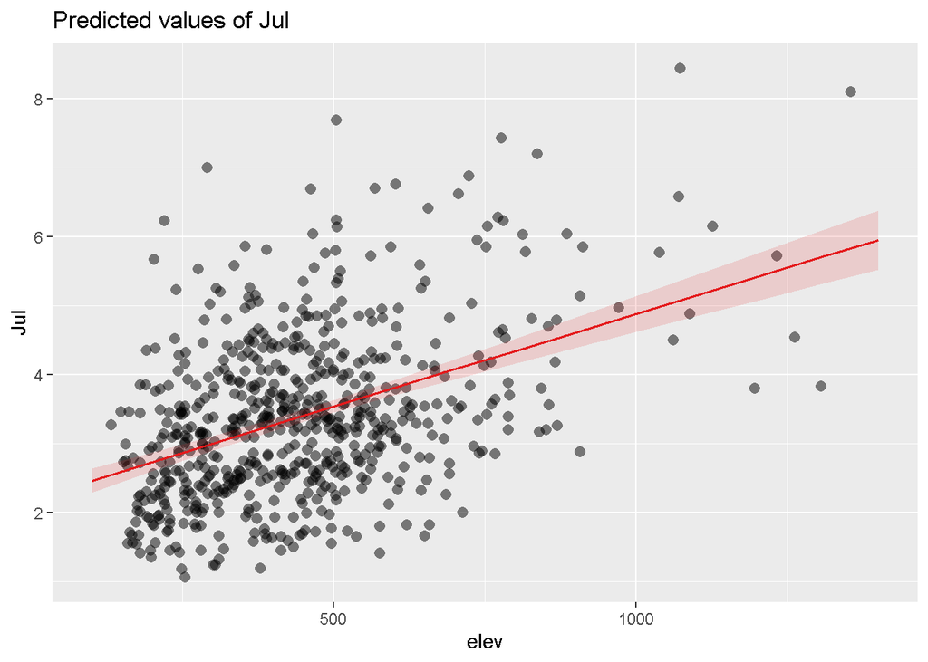

```r
plot_model(mod.ols, type="eff", terms="elev", show.data=T)
```

We see the highly narrow confidence bands, which is in accordance with the high significance of the elevation effect. However, we do not know how much is this result affected by the ignored residual spatial autocorrelation.

The first step to check the residual autocorrelation could be to plot the residuals in a map. In the following mode, we add three new columns into our data frame, one with the residuals, second with their absolute value, and the third with their sign. This enables us to plot their magnitude together with the information about their sign.

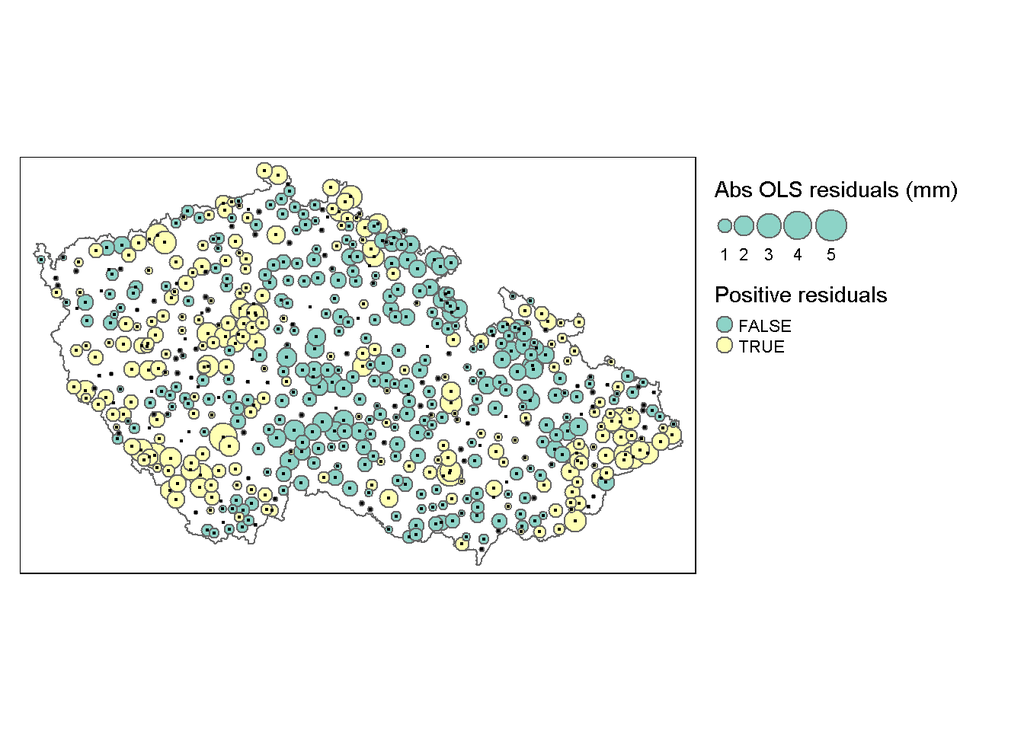

```r
# residuals
prec.sf$resid.ols <- mod.ols$residuals
prec.sf$resid.ols.abs <- abs(mod.ols$residuals)
prec.sf$resid.ols.sign <- mod.ols$residuals > 0
tm_shape(regions %>% st_union) +
  tm_borders() +
  tm_shape(prec.sf) +
  tm_bubbles(size = "resid.ols.abs", title.size = "Abs OLS residuals (mm)",
             col = "resid.ols.sign", title.col = "Positive residuals") +
  tm_shape(prec.sf) +
  tm_dots() +
  tm_layout(legend.outside = T)
```

We see a clear spatial structure in the residuals, suggesting there is still some residual autocorrelation. This can be formally checked using the methods introduced in the previous part. The methods based on Moran’s I would require to construct the spatial neighbors and assign the spatial weights, so we skip this part at the moment. We will, however, test the residual autocorrelation repeatedly later.

## Correlation

If we only need to assess the linear relationship between two continuous variables (like precipitation and elevation in our case), the simplest way is to test their correlation. In case of spatially autocorrelated data, a modification of the standard t test has been developed (Clifford and Richardson 1985) and is available in the package `SpatialPack`. Let’s compare the standard Pearson’s correlation test with the modified one.

```r
cor.test(prec.sf$Jan, prec.sf$elev)
```

```
##
##  Pearson's product-moment correlation
##
## data:  prec.sf$Jan and prec.sf$elev
## t = 6.9226, df = 632, p-value = 1.092e-11
## alternative hypothesis: true correlation is not equal to 0
## 95 percent confidence interval:
##  0.1915771 0.3363965
## sample estimates:
##       cor
## 0.2654837
```

```r
modified.ttest(prec.sf$Jan, prec.sf$elev, st_coordinates(prec.sf))
```

```
##
## Corrected Pearson's correlation for spatial autocorrelation
##
## data: x and y ; coordinates: X and Y
## F-statistic: 6.7656 on 1 and 89.2255 DF, p-value: 0.0109
## alternative hypothesis: true autocorrelation is not equal to 0
## sample correlation: 0.2655
```

We see that the modification is only for the test, the correlation coefficient itself remains unchanged. The modification actually compensates for the pseudoreplication caused by spatial autocorrelation, and reduces the effective degrees of freedom from 632 to ca 89. The correlation is still significant, but the p value increased dramatically.

For more complex situations, with possibly multiple predictors, non-linear relationships, and non-normally distributed data (e.g. disrete responses like presence/absence or counts), we need more sophisticated models. Let’s start with some of these.

## Geostatistical models

### `gstat` package and kriging

The package `gstat` reflects the classical geostatistics with its focus on spatial prediction (e.g. spatial interpolation) instead of explanatory modeling. Also, it traditionally consisted of the following three steps:

1. Visual examination of the sample variogram,
2. Fitting a theoretical model to it,
3. Using the fitted theoretical variogram to predict the values at unobserved locations (kriging).

In the following code, we compute two sample variogram, the first from the precipitation values themselves, the second from the residuals after regressing them on the elevation.

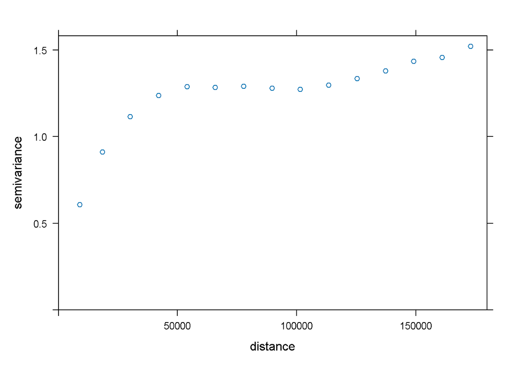

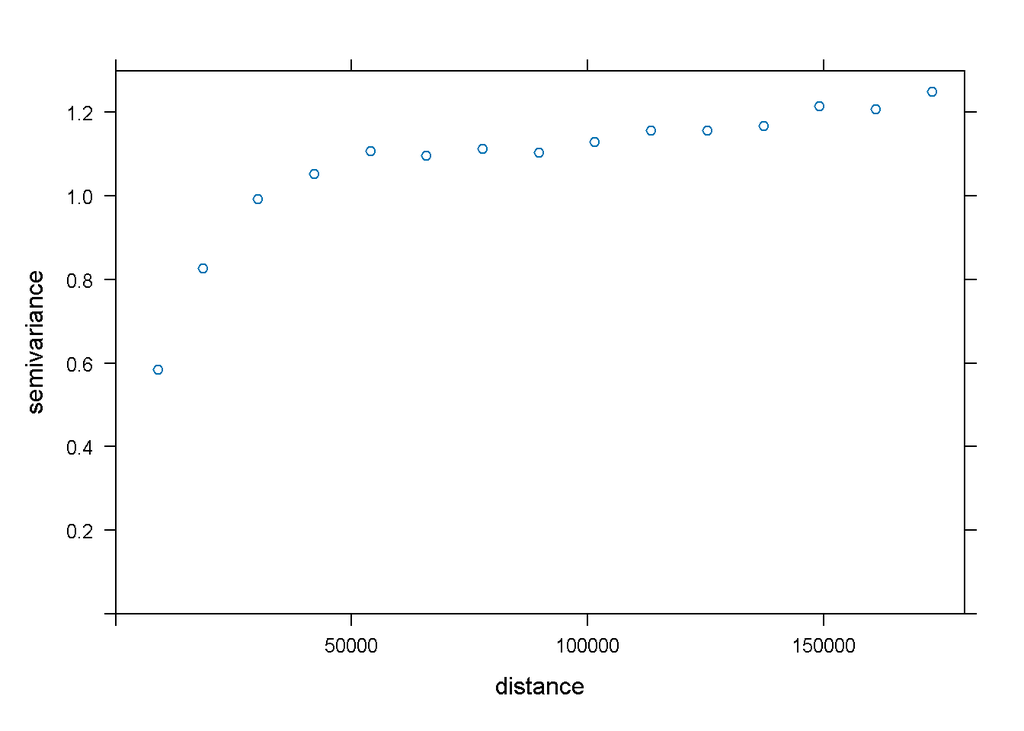

```r
vario <- variogram(Jul~1, prec.sf)
vario.elev <- variogram(Jul~elev, prec.sf)
plot(vario); plot(vario.elev)
```

Now we try to fit some theoretical model to the sample variogram. Let’s start with the traditionally ppular spherical model.

```r
(vgm.elev = fit.variogram(vario.elev, model = vgm("Sph")))
```

```
##   model     psill    range
## 1   Nug 0.3813400     0.00
## 2   Sph 0.7334163 45239.26
```

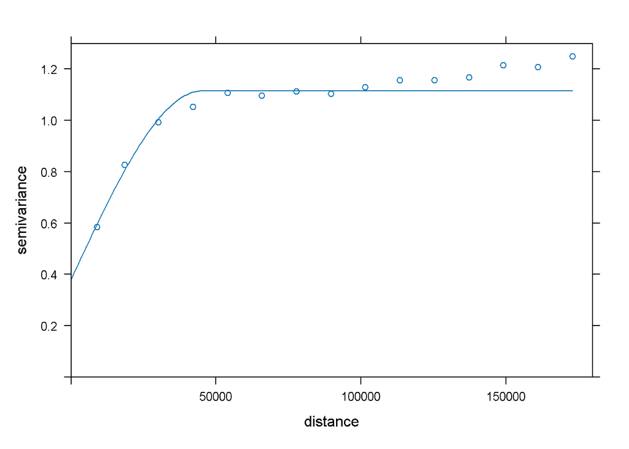

```r
plot(vario.elev, vgm.elev)
```

Although the fit looks visually good, the spherical model has only one parameter, the range, which is the value at which it reaches the sill (i.e. at which the autocorrelation decreases to zero). It is about 45 km in our case. Having only one parameter, the spherical model is not very flexible.

Let’s try another simple model, which is the exponential one.

```r
(vgm.elev = fit.variogram(vario.elev, model = vgm("Exp")))
```

```
##   model     psill    range
## 1   Nug 0.2034800     0.00
## 2   Exp 0.9398774 16971.85
```

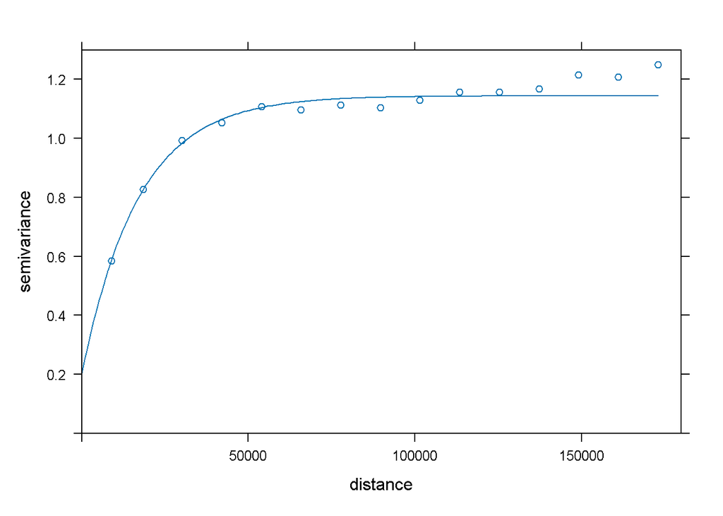

```r
plot(vario.elev, vgm.elev)
```

We can see the fit is better for a bit larger distances. It should be noted that what we only seek is the satisfying fit at relatively small distances. This has two reasons. First, the autocorrelation usually operates at smaller distances and this is where we want to capture it, either to compensate for it in explanatory models, or to employ it for spatial interpolation. Second, the sample variogram is subject to greater uncertainty at larger distances, because of lower number of pairs of observations being separated by large distances.

The much lower range parameter of the exponential variogram compared to the spherical one should not raise any concerns, it only reflects a different meaning of that parameter in the two respective models.

Wey more flexible model is the Matérn variogram, which has an additional parameter, called *kappa*, controlling the smoothness of the process by shaping the curve at its very beginning. In the default setting of the `fit.variogram` function, however, this parameter is set to 0.5, which actually reproduce the exponential model. To let the value of the *kappa* parameter be estimated, we have to set `fit.kappa = TRUE`.

```r
(vgm.elev = fit.variogram(vario.elev, model = vgm("Mat"), fit.kappa = T))
```

```
##   model     psill   range kappa
## 1   Nug 0.1108883     0.0   0.0
## 2   Mat 1.0349500 18582.6   0.4
```

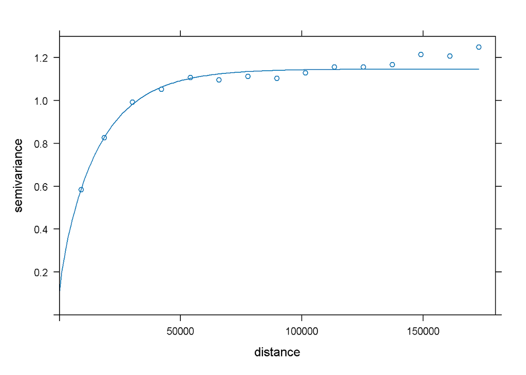

```r
plot(vario.elev, vgm.elev)
```

We see that the resulting variogram is very close to the exponential model.

It is soetimes useful to fit the variogram without the nugget effect. To achieve this, we have to set the starting value of all the variogram parameters in the `vgm` function, except the value for the nugget. Then the nugget will be automatically set to zero.

```r
(vgm.elev.zero.nugget = fit.variogram(vario.elev, model = vgm(1.2, "Exp", 50000)))
```

```
##   model    psill    range
## 1   Exp 1.118744 12861.62
```

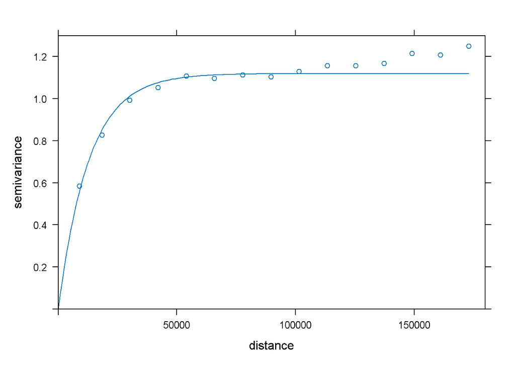

```r
plot(vario.elev, vgm.elev.zero.nugget)
```

Let’s proceed to using the variogram for spatial interpolation. Before we do that, we first try to interpolate the precipitation values by conceptually similar, but much simpler method called Inverse Distant Weighting (IDW). It estimates the unknown values by computing a weighted average of the surrounding values, where the weights are inversely proportional to the distance from the given observation to the target point of estimation. Note that here the interpolation does not takes the relationships of precipitation and elevation into account.

```r
pred.idw2.0 <- idw(Jul~1, prec.sf, newdata=dtm, idp=2)
```

```
## [inverse distance weighted interpolation]
```

```r
pred.idw0.5 <- idw(Jul~1, prec.sf, newdata=dtm, idp=0.5)
```

```
## [inverse distance weighted interpolation]
```

```r
pred.idw5.0 <- idw(Jul~1, prec.sf, newdata=dtm, idp=5)
```

```
## [inverse distance weighted interpolation]
```

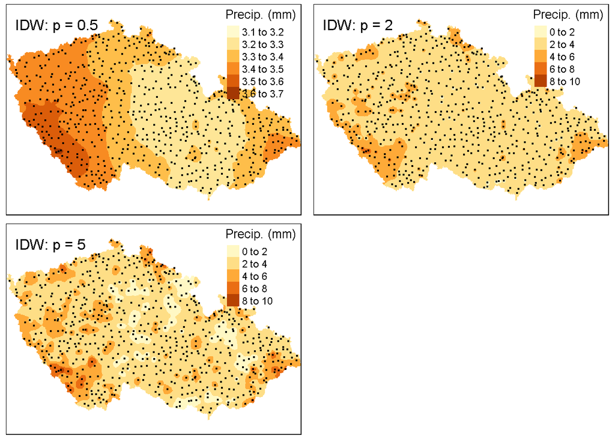

```r
plot.idw0.5 <- tm_shape(pred.idw0.5 %>% dplyr::select(var1.pred)) +
  tm_raster(title="Precip. (mm)") +
  tm_shape(prec.sf) +
  tm_dots() +
  tm_layout(legend.title.size = 1,
            legend.position = c("RIGHT","TOP"),
            title = "IDW: p = 0.5",
            title.size = 1)
plot.idw2.0 <- tm_shape(pred.idw2.0 %>% dplyr::select(var1.pred)) +
  tm_raster(title="Precip. (mm)") +
  tm_shape(prec.sf) +
  tm_dots() +
  tm_layout(legend.title.size = 1,
            legend.position = c("RIGHT","TOP"),
            title = "IDW: p = 2",
            title.size = 1)
plot.idw5.0 <- tm_shape(pred.idw5.0 %>% dplyr::select(var1.pred)) +
  tm_raster(title="Precip. (mm)") +
  tm_shape(prec.sf) +
  tm_dots() +
  tm_layout(legend.title.size = 1,
            legend.position = c("RIGHT","TOP"),
            title = "IDW: p = 5",
            title.size = 1)
tmap_arrange(plot.idw0.5,plot.idw2.0,plot.idw5.0)
```

Now we use kriging to do the interpolation, and we employ the elevation into it. This is done by the function `krige` from the package `gstat`. The kriging prediction can be done directly in a raster, but the raster layer of the predictor value (here the elevation) must be named in the same way as in the variogram formula.

Compared to IDW (and any other deterministic interpolation method), kriging not only provides the interpolated surface, but also an estimate of the corresponding uncertainty, the so called *kriging variance*.

```r
names(dtm) <- "elev"
pred.krig <- krige(Jul~elev, prec.sf, newdata=dtm, model=vgm.elev)
```

```
## [using universal kriging]
```

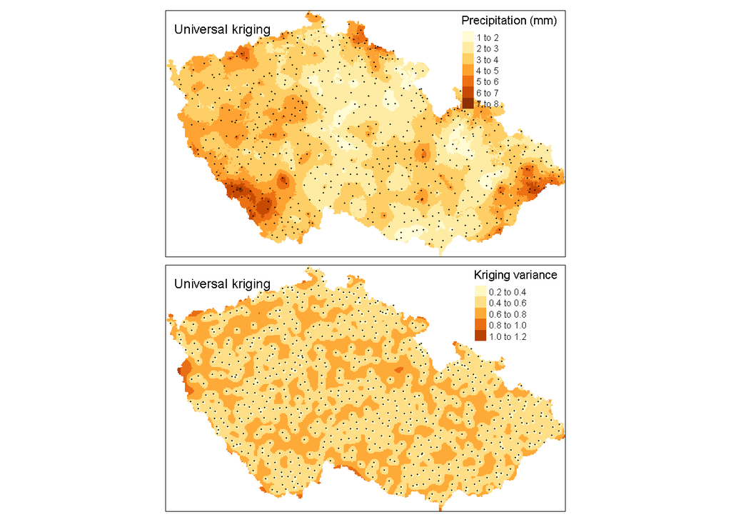

```r
tm_shape(pred.krig) +
  tm_raster(title=c("Precipitation (mm)", "Kriging variance")) +
  tm_shape(prec.sf) +
  tm_dots() +
  tm_layout(title = "Universal kriging",
            title.size = 1,
            legend.position = c("RIGHT","TOP"),)
```

### Mixed model approach

We can fit linear models with correlated errors directly using generalized least squares by the `gls` function from the `nlme` package. It can accommodate few types of covariance functions to construct the general covariance matrix. In the following example, we again use the exponential covariance function with nugget effect.

```r
mod.gls <- gls(Jul~elev,
               data = prec.sf %>% st_drop_geometry,
               correlation = corExp(form = ~x+y, nugget=T))
summary(mod.gls)
```

```
## Generalized least squares fit by REML
##   Model: Jul ~ elev
##   Data: prec.sf %>% st_drop_geometry
##        AIC     BIC    logLik
##   1671.308 1693.56 -830.6539
##
## Correlation Structure: Exponential spatial correlation
##  Formula: ~x + y
##  Parameter estimate(s):
##        range       nugget
## 23643.884414     0.254642
##
## Coefficients:
##                 Value  Std.Error   t-value p-value
## (Intercept) 2.6143186 0.21364316 12.236846       0
## elev        0.0019329 0.00029013  6.662101       0
##
##  Correlation:
##      (Intr)
## elev -0.623
##
## Standardized residuals:
##        Min         Q1        Med         Q3        Max
## -2.1033806 -0.7782393 -0.1879662  0.4607748  3.7169397
##
## Residual standard error: 1.103554
## Degrees of freedom: 635 total; 633 residual
```

This model-based approach enables us to assess the significance of the predictors.

```r
car::Anova(mod.gls)
```

```
## Analysis of Deviance Table (Type II tests)
##
## Response: Jul
##      Df  Chisq Pr(>Chisq)
## elev  1 44.384  2.699e-11 ***
## ---
## Signif. codes:  0 '***' 0.001 '**' 0.01 '*' 0.05 '.' 0.1 ' ' 1
```

```r
# anova(mod.gls, update(mod.gls, ~.-elev))
```

To see the effect of the fixed predictors, we can again use the function `plot_model` from the package `sjPlot`.

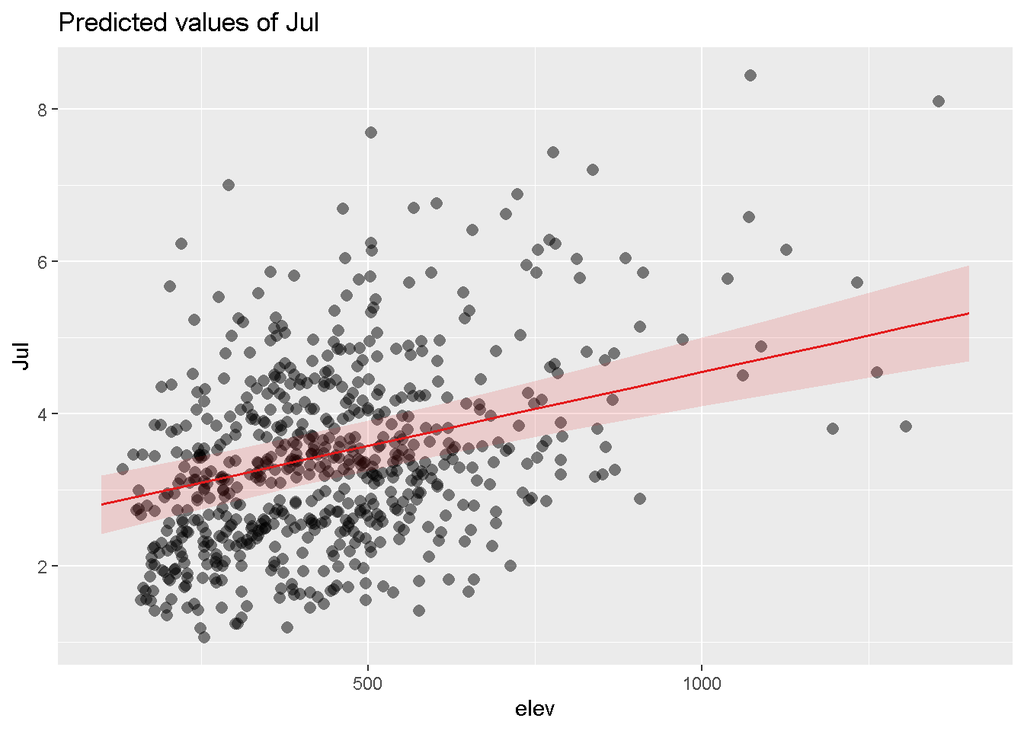

```r
plot_model(mod.gls, type="eff", terms="elev", show.data = T)
```

Note the wider confidence bands compared to those obtained from the OLS model. This is the effect of accounting for the spatial autocorrelation, similarly as when using the modified t test of correlation coefficient instead of the standard one assuming independence.

To see the explained variability of the model, we can call the function `r2` from the package `performance`. This generic function computes the appropriate versions of the R squared values for different types of models.

```r
r2(mod.gls)
```

```
##   R2: 0.164
```

```r
r2(mod.ols)
```

```
## # R2 for Linear Regression
##        R2: 0.183
##   adj. R2: 0.182
```

Another way how to fit (generalized) linear mixed models with spatial effect is the package `spaMM`. The advantage compared to the `gls` function is that it can fit models for other than normally distributed responses.

```r
mod.spaMM <- fitme(Jul~elev+Matern(1|x+y), data=prec.sf, fixed=list(nu=1.5))
summary(mod.spaMM, verbose=T)
```

```
## formula: Jul ~ elev + Matern(1 | x + y)
## ML: Estimation of corrPars, lambda and phi by ML.
##     Estimation of fixed effects by ML.
## Estimation of lambda and phi by 'outer' ML, maximizing logL.
## family: gaussian( link = identity )
##  ------------ Fixed effects (beta) ------------
##             Estimate  Cond. SE t-value
## (Intercept) 2.546384 0.1803770  14.117
## elev        0.001992 0.0002878   6.921
##  --------------- Random effects ---------------
## Family: gaussian( link = identity )
##                    --- Correlation parameters:
##         1.nu        1.rho
## 1.500000e+00 9.292604e-05
##            --- Variance parameters ('lambda'):
## lambda = var(u) for u ~ Gaussian;
##    x + y  :  0.7004
## # of obs: 635; # of groups: x + y, 635
##  -------------- Residual variance  ------------
## phi estimate was 0.455152
##  ------------- Likelihood values  -------------
##                         logLik
## logL       (p_v(h)): -825.0289
```

```r
drop1(mod.spaMM, test="Chisq")
```

```
## Likelihood-ratio tests for single-term deletions
##
## Model:
## Jul ~ elev + Matern(1 | x + y)
##      chi2_LR df   p_value
## elev  42.618  1 6.654e-11
```

```r
fixlrt <- fixedLRT(Jul~1+Matern(1|x+y), Jul~elev+Matern(1|x+y),
                   method="ML", data=prec.sf, ranFix=list(nu=1.5))
summary(fixlrt,verbose=FALSE)
```

```
##    chi2_LR df      p_value
## 1 42.61813  1 6.653966e-11
```

Similar options are available in the package `glmmTMB`, which is another great package for fitting GLMM models, which also includes spatial random effects.

```r
d <- prec.sf %>% mutate(pos = numFactor(prec.sf$x, prec.sf$y), group = factor(rep(1, nrow(prec.sf))))
mod.TMB <- glmmTMB(Jul ~ elev + exp(pos + 0 | group), data=d)
s <- summary(mod.TMB)
names(s)
```

```
##  [1] "logLik"       "family"       "link"         "ngrps"        "nobs"
##  [6] "coefficients" "sigma"        "vcov"         "varcor"       "AICtab"
## [11] "call"
```

```r
s$coefficients
```

```
## $cond
##                Estimate Std. Error z value Pr(>|z|)
## (Intercept) 2.196298767        NaN     NaN      NaN
## elev        0.002683651        NaN     NaN      NaN
##
## $zi
## NULL
##
## $disp
## NULL
```

```r
drop1(mod.TMB, test="Chisq")
```

```
## Single term deletions
##
## Model:
## Jul ~ elev + exp(pos + 0 | group)
##        Df AIC LRT Pr(>Chi)
## <none>
## elev    1
```

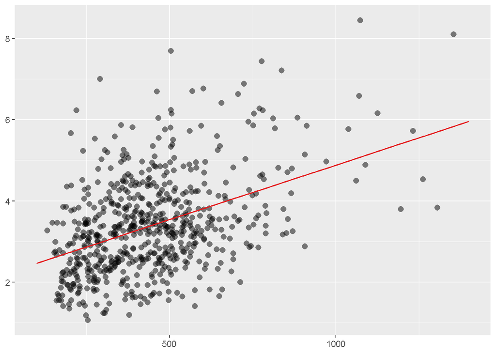

```r
plot_model(mod.TMB, type="eff", terms="elev", show.data=T)
```

## Autoregressive models

```r
nb <- knn2nb(knearneigh(st_coordinates(prec.sf), k=12), sym=T)
lw <- nb2listwdist(nb, prec.sf, type="idw", alpha=1)

mod.sar <- spautolm(Jul~elev, data=prec.sf, listw = lw, family = "SAR")
summary(mod.sar)
```

```
##
## Call:
## spautolm(formula = Jul ~ elev, data = prec.sf, listw = lw, family = "SAR")
##
## Residuals:
##      Min       1Q   Median       3Q      Max
## -2.18845 -0.63221 -0.13020  0.46871  3.96443
##
## Coefficients:
##               Estimate Std. Error z value  Pr(>|z|)
## (Intercept) 2.30066560 0.15601073 14.7468 < 2.2e-16
## elev        0.00231869 0.00028745  8.0664 6.661e-16
##
## Lambda: 769.7 LR test value: 238.33 p-value: < 2.22e-16
## Numerical Hessian standard error of lambda: 34.063
##
## Log likelihood: -834.1107
## ML residual variance (sigma squared): 0.74793, (sigma: 0.86483)
## Number of observations: 635
## Number of parameters estimated: 4
## AIC: NA (not available for weighted model)
```

```r
moran.mc(mod.sar$fit$residuals, lw, 999)
```

```
##
##  Monte-Carlo simulation of Moran I
##
## data:  mod.sar$fit$residuals
## weights: lw
## number of simulations + 1: 1000
##
## statistic = 0.017337, observed rank = 867, p-value = 0.133
## alternative hypothesis: greater
```

```r
mod.car <- spautolm(Jul~elev, data=prec.sf, listw = lw, family = "CAR")
summary(mod.car)
```

```
##
## Call:
## spautolm(formula = Jul ~ elev, data = prec.sf, listw = lw, family = "CAR")
##
## Residuals:
##      Min       1Q   Median       3Q      Max
## -2.36372 -0.60752 -0.12047  0.46216  3.91721
##
## Coefficients:
##               Estimate Std. Error z value  Pr(>|z|)
## (Intercept) 2.14802395 0.13468536 15.9485 < 2.2e-16
## elev        0.00265259 0.00026906  9.8587 < 2.2e-16
##
## Lambda: 857.32 LR test value: 206.48 p-value: < 2.22e-16
## Numerical Hessian standard error of lambda: 7.6798
##
## Log likelihood: -850.0353
## ML residual variance (sigma squared): 0.80104, (sigma: 0.89501)
## Number of observations: 635
## Number of parameters estimated: 4
## AIC: NA (not available for weighted model)
```

```r
moran.mc(mod.car$fit$residuals, lw, 999)
```

```
##
##  Monte-Carlo simulation of Moran I
##
## data:  mod.car$fit$residuals
## weights: lw
## number of simulations + 1: 1000
##
## statistic = -0.019174, observed rank = 151, p-value = 0.849
## alternative hypothesis: greater
```

```r
# mod.sac <- sacsarlm(Jul~elev, data=prec.sf, listw = lw)
# summary(mod.sac)
# moran.mc(mod.sac$residuals, lw, 999)
#
# # 1 - logLik(mod.sar)/logLik(sacsarlm(Jul~1, data=prec.sf, listw = lw))
#
# mod.err <- errorsarlm(Jul~elev, data=prec.sf, listw = lw)
# summary(mod.err)
# moran.mc(mod.err$residuals, lw, 999)
#
# mod.lag <- lagsarlm(Jul~elev, data=prec.sf, listw = lw)
# summary(mod.lag)
# moran.mc(mod.lag$residuals, lw, 999)
```

## Autocovariate models

```r
prec.sf$autocov <- autocov_dist(prec.sf$Jul, st_coordinates(prec.sf), nbs = 50000, type = "inverse", style="W")
mod.aclm <- lm(Jul~elev+autocov, data=prec.sf)
lm.morantest.exact(mod.aclm, lw)
```

```
##
##  Global Moran I statistic with exact p-value
##
## data:
## model:lm(formula = Jul ~ elev + autocov, data = prec.sf)
## weights: lw
##
## Exact standard deviate = 5.2762, p-value = 6.593e-08
## alternative hypothesis: greater
## sample estimates:
## [1] 0.1032737
```

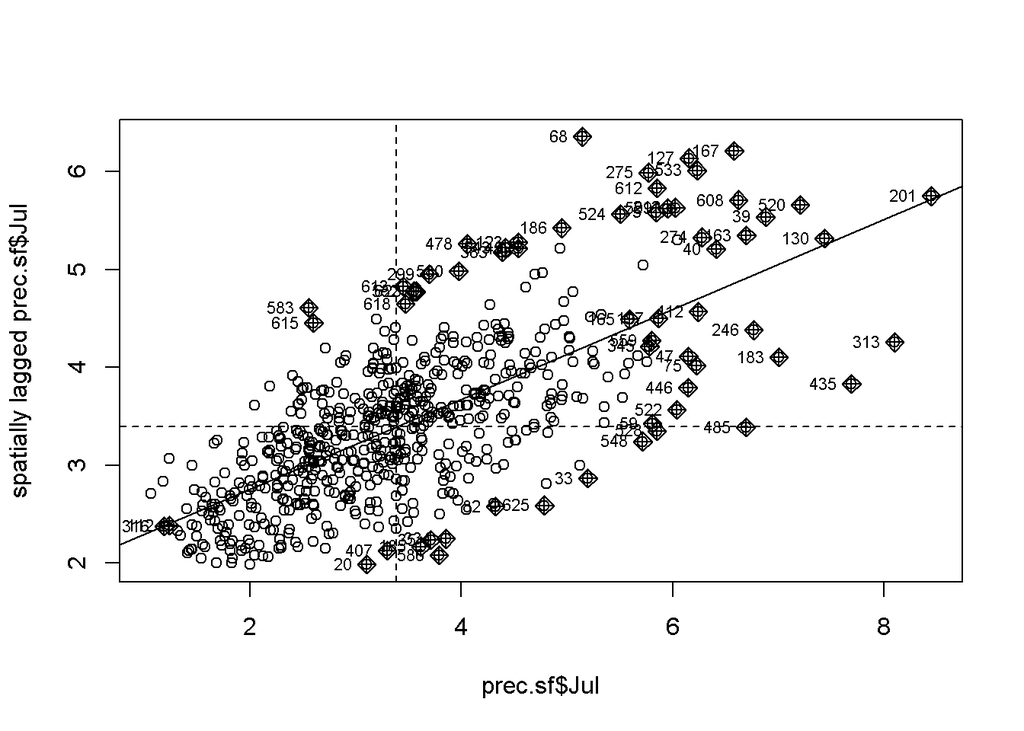

```r
morpl <- moran.plot(prec.sf$Jul, nb2listwdist(nb, prec.sf, type="idw", alpha=1, style = "W"))
```

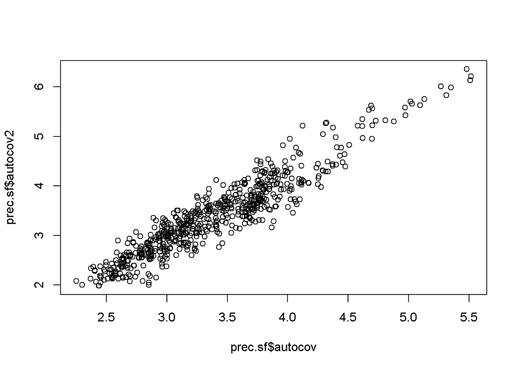

```r
prec.sf$autocov2 <- morpl$wx
plot(prec.sf$autocov, prec.sf$autocov2)
```

```r
mod.aclm <- lm(Jul~elev+autocov2, data=prec.sf)
lm.morantest.exact(mod.aclm, lw)
```

```
##
##  Global Moran I statistic with exact p-value
##
## data:
## model:lm(formula = Jul ~ elev + autocov2, data = prec.sf)
## weights: lw
##
## Exact standard deviate = -3.2002, p-value = 0.9993
## alternative hypothesis: greater
## sample estimates:
## [1] -0.05336869
```

```r
summary(mod.aclm)
```

```
##
## Call:
## lm(formula = Jul ~ elev + autocov2, data = prec.sf)
##
## Residuals:
##     Min      1Q  Median      3Q     Max
## -2.2250 -0.5727 -0.1075  0.4352  3.8232
##
## Coefficients:
##               Estimate Std. Error t value Pr(>|t|)
## (Intercept) -0.2975557  0.1491453  -1.995   0.0465 *
## elev         0.0008381  0.0001974   4.246  2.5e-05 ***
## autocov2     0.9767927  0.0480833  20.315  < 2e-16 ***
## ---
## Signif. codes:  0 '***' 0.001 '**' 0.01 '*' 0.05 '.' 0.1 ' ' 1
##
## Residual standard error: 0.8465 on 632 degrees of freedom
## Multiple R-squared:  0.506,  Adjusted R-squared:  0.5044
## F-statistic: 323.6 on 2 and 632 DF,  p-value: < 2.2e-16
```

```r
mod.acrf <- ranger(Jul~elev+autocov2, data=prec.sf %>% st_drop_geometry, importance = "impurity")
mod.acrf$variable.importance
```

```
##     elev autocov2
## 294.8790 554.5881
```

```r
mod.acrf$prediction.error
```

```
## [1] 0.82895
```

```r
resid.acrf <- mod.acrf$predictions - prec.sf$Jul
moran.mc(resid.acrf, lw, nsim=999)
```

```
##
##  Monte-Carlo simulation of Moran I
##
## data:  resid.acrf
## weights: lw
## number of simulations + 1: 1000
##
## statistic = -0.034791, observed rank = 16, p-value = 0.984
## alternative hypothesis: greater
```

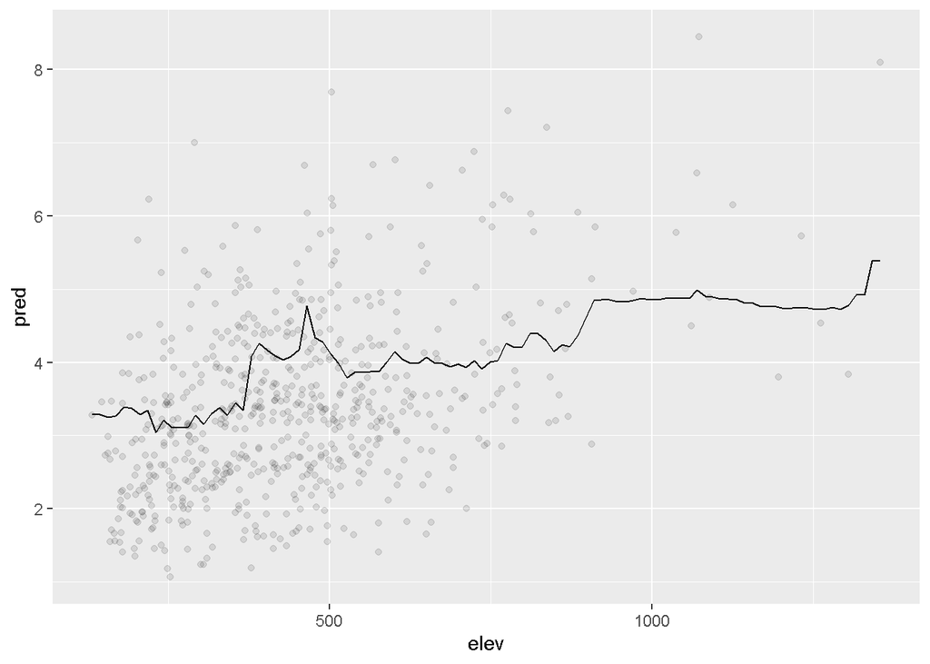

```r
newdat <- data.frame(elev = seq(min(prec.sf$elev), max(prec.sf$elev), l=100),
                     autocov2 = mean(prec.sf$autocov2))
newdat$pred <- predict(mod.acrf, data=newdat)$predictions
ggplot(newdat, aes(x=elev, y=pred)) +
  geom_point(data=prec.sf, aes(y=Jul), alpha=.1) +
  geom_line()
```

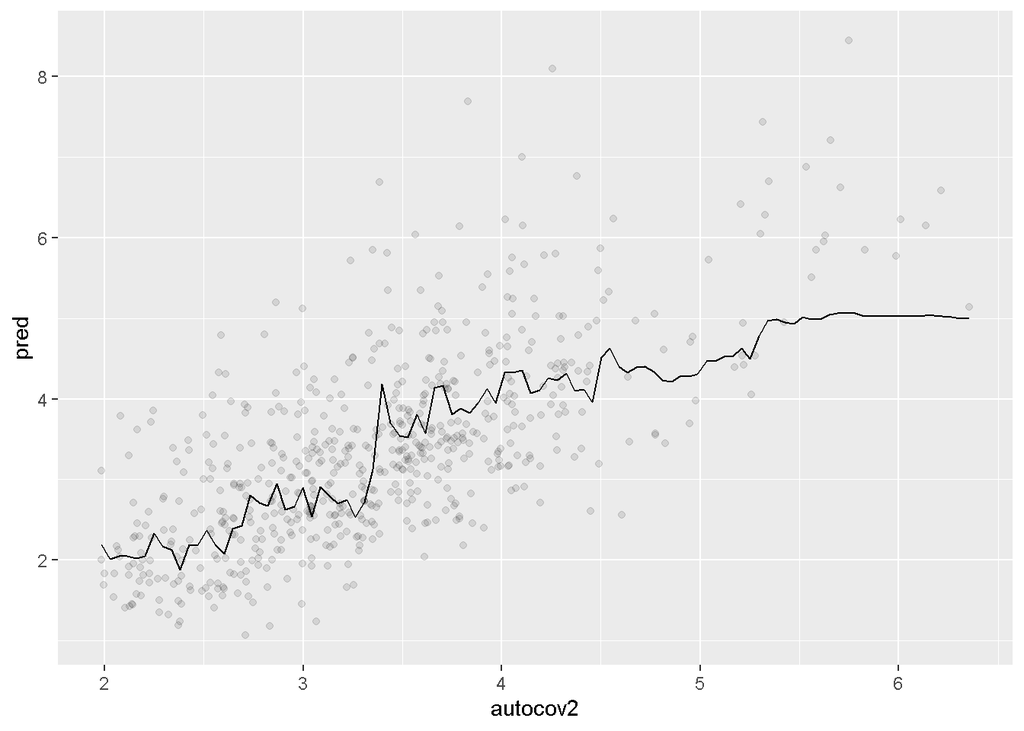

```r
newdat <- data.frame(autocov2 = seq(min(prec.sf$autocov2), max(prec.sf$autocov2), l=100),
                     elev = mean(prec.sf$elev))
newdat$pred <- predict(mod.acrf, data=newdat)$predictions
ggplot(newdat, aes(x=autocov2, y=pred)) +
  geom_point(data=prec.sf, aes(y=Jul), alpha=.1) +
  geom_line()
```

## Using space as fixed predictor

### GAMs

```r
mod.gam <- gam(Jul ~ elev + s(x, y), data=prec.sf %>% st_drop_geometry)
summary(mod.gam)
```

```
##
## Family: gaussian
## Link function: identity
##
## Formula:
## Jul ~ elev + s(x, y)
##
## Parametric coefficients:
##              Estimate Std. Error t value Pr(>|t|)
## (Intercept) 2.4978669  0.1297530   19.25  < 2e-16 ***
## elev        0.0020040  0.0002807    7.14 2.69e-12 ***
## ---
## Signif. codes:  0 '***' 0.001 '**' 0.01 '*' 0.05 '.' 0.1 ' ' 1
##
## Approximate significance of smooth terms:
##          edf Ref.df     F p-value
## s(x,y) 26.51  28.62 9.413  <2e-16 ***
## ---
## Signif. codes:  0 '***' 0.001 '**' 0.01 '*' 0.05 '.' 0.1 ' ' 1
##
## R-sq.(adj) =  0.419   Deviance explained = 44.4%
## GCV = 0.87932  Scale est. = 0.83984   n = 635
```

```r
moran.mc(mod.gam$residuals, lw, 999)
```

```
##
##  Monte-Carlo simulation of Moran I
##
## data:  mod.gam$residuals
## weights: lw
## number of simulations + 1: 1000
##
## statistic = 0.16151, observed rank = 1000, p-value = 0.001
## alternative hypothesis: greater
```

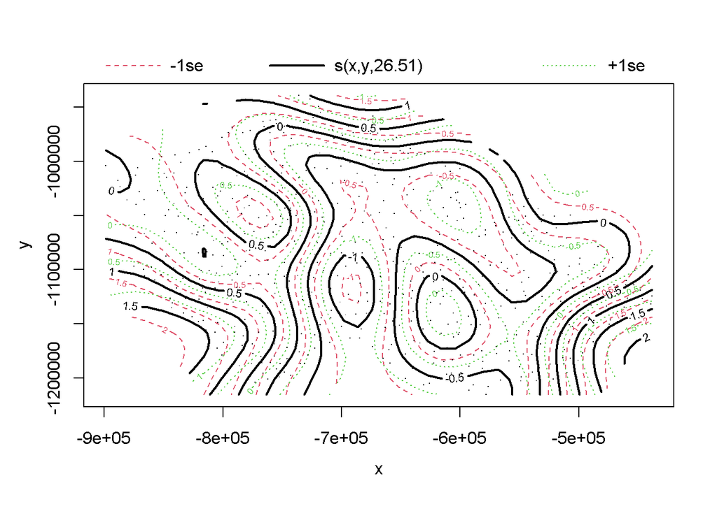

```r
plot(mod.gam)
```

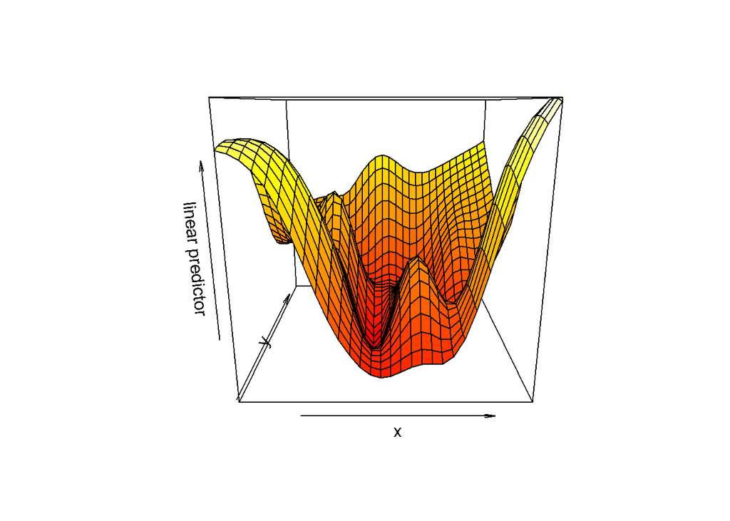

```r
vis.gam(mod.gam, view = c("x","y"))
```

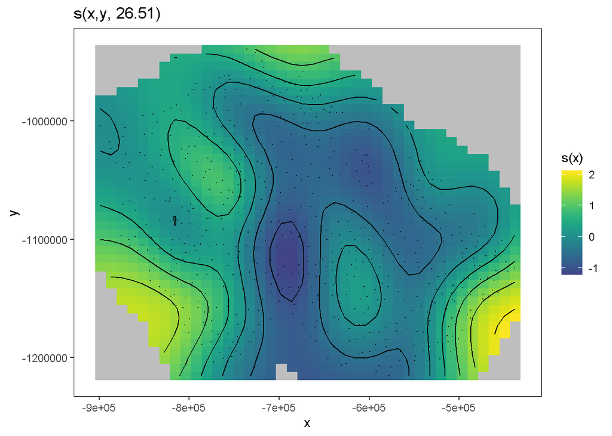

```r
p <- getViz(mod.gam)
plot(sm(p, 1)) +
  l_fitRaster() +
  l_fitContour() +
  l_points()
```

```r
r2(mod.gam)
```

```
## $R2
## Adjusted R2
##   0.4191392
```

```r
mod.gam <- gam(Jul ~ s(elev) + s(x, y, k=100), data=prec.sf %>% st_drop_geometry)
summary(mod.gam)
```

```
##
## Family: gaussian
## Link function: identity
##
## Formula:
## Jul ~ s(elev) + s(x, y, k = 100)
##
## Parametric coefficients:
##             Estimate Std. Error t value Pr(>|t|)
## (Intercept)  3.38712    0.03154   107.4   <2e-16 ***
## ---
## Signif. codes:  0 '***' 0.001 '**' 0.01 '*' 0.05 '.' 0.1 ' ' 1
##
## Approximate significance of smooth terms:
##           edf Ref.df     F  p-value
## s(elev)  1.00   1.00 27.66 2.92e-07 ***
## s(x,y)  77.75  91.72  6.17  < 2e-16 ***
## ---
## Signif. codes:  0 '***' 0.001 '**' 0.01 '*' 0.05 '.' 0.1 ' ' 1
##
## R-sq.(adj) =  0.563   Deviance explained = 61.7%
## GCV = 0.72238  Scale est. = 0.63166   n = 635
```

```r
moran.mc(mod.gam$residuals, lw, 999)
```

```
##
##  Monte-Carlo simulation of Moran I
##
## data:  mod.gam$residuals
## weights: lw
## number of simulations + 1: 1000
##
## statistic = -0.045181, observed rank = 3, p-value = 0.997
## alternative hypothesis: greater
```

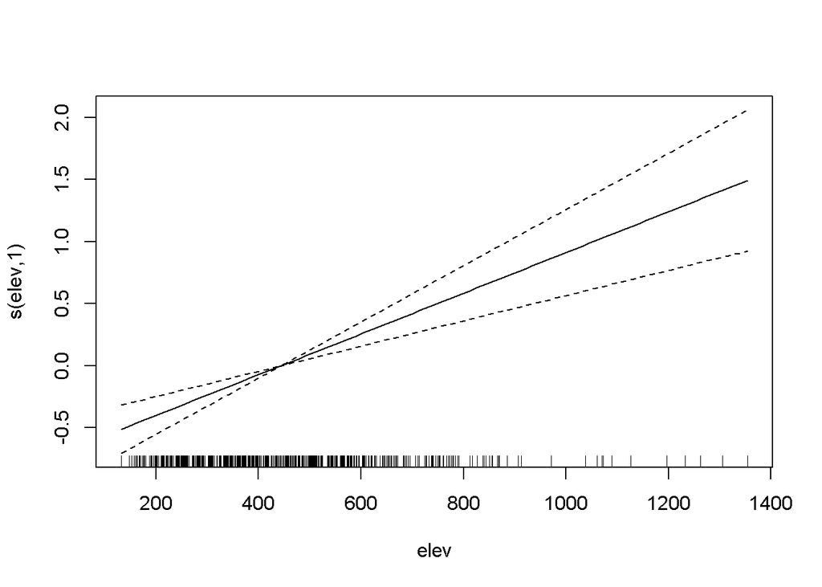

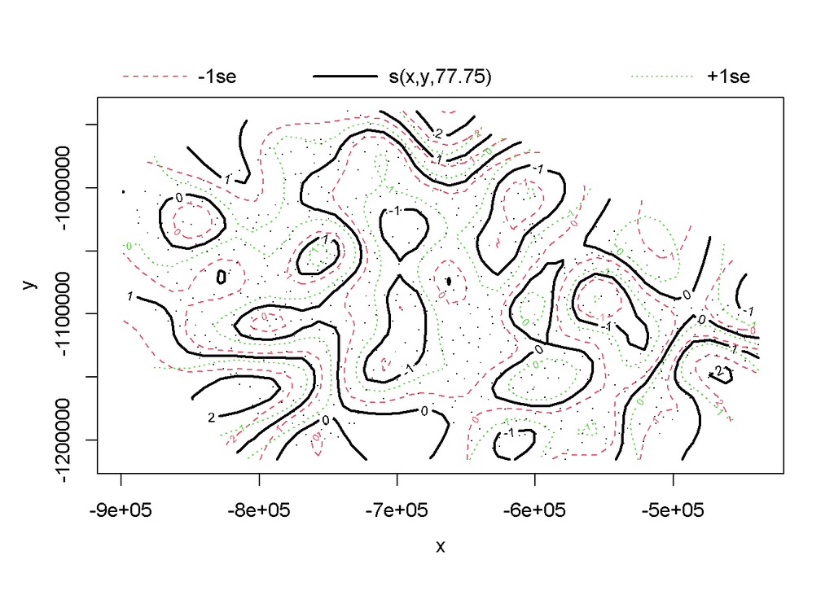

```r
plot(mod.gam)
```

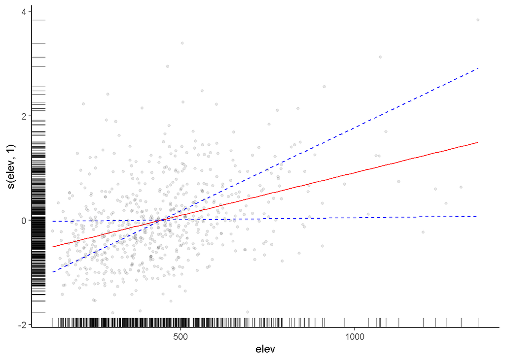

```r
p <- getViz(mod.gam)
plot(sm(p, 1)) +
  l_fitLine(colour = "red") +
  l_rug(mapping = aes(x=x, y=y), alpha = 0.8) +
  l_ciLine(mul = 5, colour = "blue", linetype = 2) +
  l_points(shape = 19, size = 1, alpha = 0.1) +
  theme_classic()
```

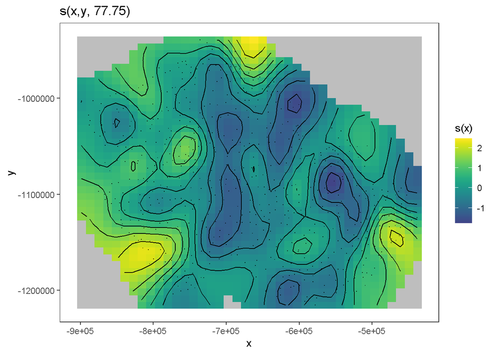

```r
plot(sm(p, 2)) +
  l_fitRaster() +
  l_fitContour() +
  l_points()
```

```r
r2(mod.gam)
```

```
## $R2
## Adjusted R2
##    0.563121
```

### Random Forests

```r
mod.rf <- ranger(Jul~elev+x+y, data=prec.sf %>% st_drop_geometry,importance = "impurity")
mod.rf$variable.importance
```

```
##     elev        x        y
## 279.3462 318.6672 239.7579
```

```r
mod.rf$prediction.error
```

```
## [1] 0.8042445
```

```r
resid.rf <- mod.rf$predictions - prec.sf$Jul
moran.mc(resid.rf, lw, nsim=999)
```

```
##
##  Monte-Carlo simulation of Moran I
##
## data:  resid.rf
## weights: lw
## number of simulations + 1: 1000
##
## statistic = 0.051466, observed rank = 999, p-value = 0.001
## alternative hypothesis: greater
```

## Moran’s eigenvector mapping

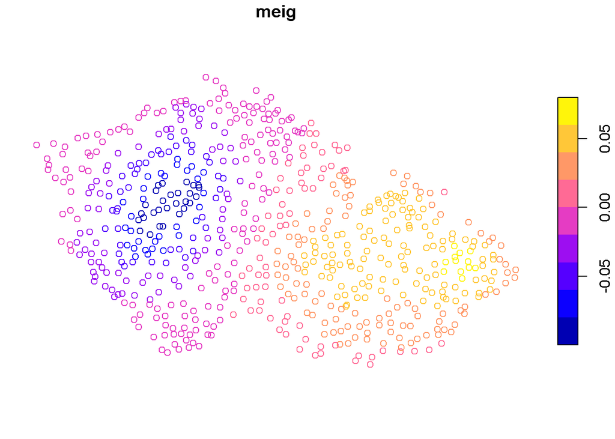

```r
meig <- meigen(st_coordinates(prec.sf))
plot(prec.sf %>% mutate(meig = meig$sf[,1]) %>% select(meig))
```

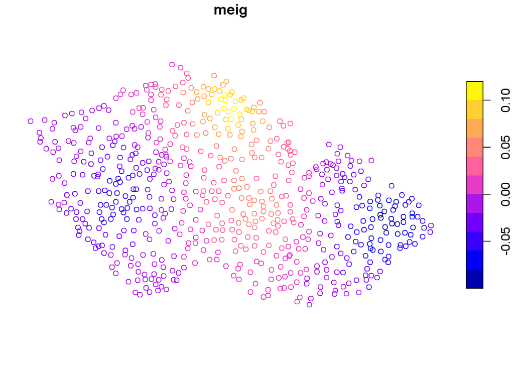

```r
plot(prec.sf %>% mutate(meig = meig$sf[,2]) %>% select(meig))
```

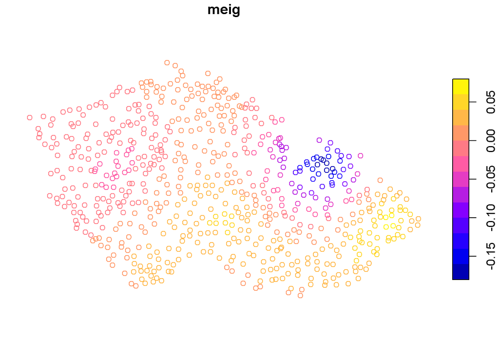

```r
plot(prec.sf %>% mutate(meig = meig$sf[,5]) %>% select(meig))
```

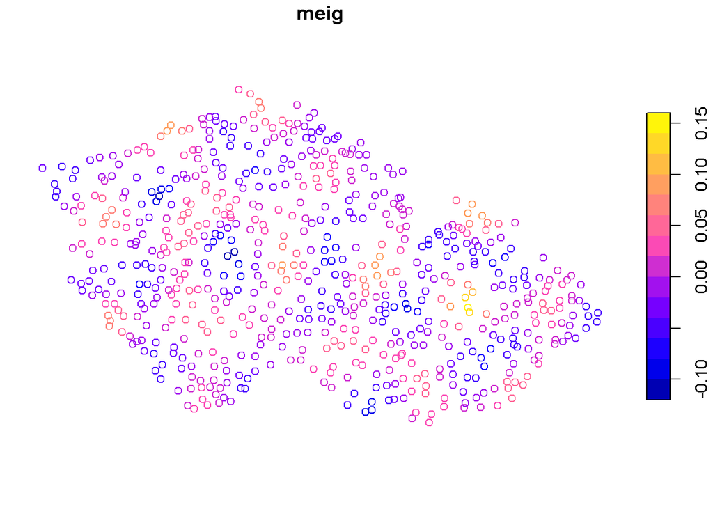

```r
plot(prec.sf %>% mutate(meig = meig$sf[,50]) %>% select(meig))
```

```r
df <- cbind(prec.sf %>% select(elev, Jul) %>% st_drop_geometry,
            meig$sf %>% as.data.frame %>% set_names(paste("eig",1:ncol(meig$sf), sep="")))
formula <- paste(c("Jul~elev", paste("eig", 1:ncol(meig$sf), sep="")), collapse = "+")

mod.meiglm <- lm(formula, data=df) %>% step(trace = 0)

summary(mod.meiglm)
```

```
##
## Call:
## lm(formula = Jul ~ elev + eig1 + eig2 + eig3 + eig4 + eig5 +
##     eig6 + eig8 + eig10 + eig12 + eig13 + eig14 + eig15 + eig16 +
##     eig17 + eig20 + eig21 + eig22 + eig23 + eig24 + eig26 + eig27 +
##     eig28 + eig29 + eig30 + eig31 + eig32 + eig33 + eig35 + eig36 +
##     eig41 + eig42 + eig43 + eig46 + eig51 + eig52 + eig57 + eig59 +
##     eig60 + eig61 + eig62 + eig63 + eig66 + eig68 + eig70 + eig73 +
##     eig75 + eig78 + eig80 + eig82 + eig83 + eig86 + eig87 + eig88 +
##     eig89 + eig92 + eig95 + eig96 + eig98 + eig105 + eig106 +
##     eig108 + eig111 + eig112 + eig114 + eig117 + eig118 + eig119 +
##     eig121 + eig123 + eig124 + eig125 + eig135, data = df)
##
## Residuals:
##     Min      1Q  Median      3Q     Max
## -1.8299 -0.4788 -0.0915  0.3896  2.7324
##
## Coefficients:
##               Estimate Std. Error t value Pr(>|t|)
## (Intercept)  2.6208199  0.1212626  21.613  < 2e-16 ***
## elev         0.0017269  0.0002653   6.510 1.67e-10 ***
## eig1        -4.7688654  0.7342907  -6.495 1.84e-10 ***
## eig2        -6.2621056  0.7350492  -8.519  < 2e-16 ***
## eig3         2.7332811  0.7469565   3.659 0.000277 ***
## eig4         2.0090097  0.9081885   2.212 0.027361 *
## eig5         2.7414587  0.7763081   3.531 0.000447 ***
## eig6         2.9528480  0.7640661   3.865 0.000124 ***
## eig8        -2.0478868  0.7726274  -2.651 0.008263 **
## eig10       -5.4496107  0.7340109  -7.424 4.23e-13 ***
## eig12        1.7123633  0.7435056   2.303 0.021638 *
## eig13       -3.2285249  0.7361900  -4.385 1.38e-05 ***
## eig14       -2.6341897  0.7594054  -3.469 0.000563 ***
## eig15       -3.4437801  0.7340818  -4.691 3.41e-06 ***
## eig16       -1.7708379  0.7780058  -2.276 0.023215 *
## eig17        7.0987612  0.8069867   8.797  < 2e-16 ***
## eig20        1.6223413  0.7340164   2.210 0.027492 *
## eig21        4.8715664  0.7717325   6.313 5.58e-10 ***
## eig22        2.8314573  0.7728464   3.664 0.000272 ***
## eig23        1.9580736  0.7343124   2.667 0.007885 **
## eig24        1.4087397  0.7417720   1.899 0.058057 .
```

[output cut: 44 more lines]

```
## eig114      -1.6846186  0.7350238  -2.292 0.022280 *
## eig117       1.9614447  0.7347743   2.669 0.007818 **
## eig118       1.2693365  0.7359104   1.725 0.085105 .
## eig119      -1.2701806  0.7347268  -1.729 0.084399 .
## eig121       2.1343094  0.7340250   2.908 0.003785 **
## eig123      -1.0573712  0.7340400  -1.440 0.150289
## eig124       1.0159898  0.7387238   1.375 0.169578
## eig125      -1.6712227  0.7370810  -2.267 0.023748 *
## eig135      -1.4337270  0.7340119  -1.953 0.051284 .
## ---
## Signif. codes:  0 '***' 0.001 '**' 0.01 '*' 0.05 '.' 0.1 ' ' 1
##
## Residual standard error: 0.734 on 561 degrees of freedom
## Multiple R-squared:  0.6703, Adjusted R-squared:  0.6274
## F-statistic: 15.62 on 73 and 561 DF,  p-value: < 2.2e-16
```

```r
car::vif(mod.meiglm)
```

```
##     elev     eig1     eig2     eig3     eig4     eig5     eig6     eig8
## 3.048377 1.000764 1.002833 1.035586 1.530903 1.118572 1.083571 1.107990
##    eig10    eig12    eig13    eig14    eig15    eig16    eig17    eig20
## 1.000002 1.026040 1.005948 1.070393 1.000195 1.123470 1.208728 1.000017
##    eig21    eig22    eig23    eig24    eig26    eig27    eig28    eig29
## 1.105425 1.108618 1.000823 1.021261 1.020012 1.050873 1.006935 1.021740
##    eig30    eig31    eig32    eig33    eig35    eig36    eig41    eig42
## 1.000959 1.031149 1.005281 1.003693 1.060946 1.060969 1.002574 1.034860
##    eig43    eig46    eig51    eig52    eig57    eig59    eig60    eig61
## 1.000349 1.008598 1.007485 1.000010 1.000155 1.014024 1.003081 1.005085
##    eig62    eig63    eig66    eig68    eig70    eig73    eig75    eig78
## 1.024724 1.000185 1.001351 1.007811 1.002338 1.009788 1.002786 1.000351
##    eig80    eig82    eig83    eig86    eig87    eig88    eig89    eig92
## 1.003308 1.000443 1.000265 1.001695 1.011712 1.005913 1.010834 1.002192
##    eig95    eig96    eig98   eig105   eig106   eig108   eig111   eig112
## 1.001170 1.000152 1.009118 1.010512 1.000033 1.001490 1.011282 1.005627
##   eig114   eig117   eig118   eig119   eig121   eig123   eig124   eig125
## 1.002764 1.002083 1.005184 1.001953 1.000040 1.000081 1.012884 1.008384
##   eig135
## 1.000005
```

```r
mod.meigrf <- ranger(formula, data=df, importance = "impurity")
mod.meigrf$variable.importance %>% sort(decreasing = T)
```

```
##      elev     eig17      eig2      eig4     eig21      eig5     eig24     eig10
## 37.472412 34.230627 26.640734 22.207591 16.549379 15.541375 15.458815 15.290358
##      eig1      eig8     eig18     eig29     eig20     eig87    eig100     eig15
## 14.630900 12.646434 11.946457 11.292630 11.110788 10.887101  9.802522  9.676401
##     eig27     eig14     eig34     eig46     eig30     eig23     eig22     eig31
##  9.611336  9.563901  9.542555  9.353877  8.527640  8.518120  8.114994  8.105942
##     eig36      eig6      eig3     eig12     eig19     eig26    eig122     eig66
##  7.900238  7.675367  7.492937  7.288862  7.237036  6.806159  6.639105  6.638127
##     eig89     eig13     eig35     eig94    eig121     eig80     eig65    eig114
##  6.600061  6.433211  6.295540  6.166885  6.154434  6.133511  6.093189  6.028398
##    eig105     eig71     eig32     eig85     eig52     eig91     eig72     eig25
##  5.972635  5.971763  5.954932  5.943006  5.890504  5.866542  5.851387  5.832480
##     eig11     eig48     eig16     eig67     eig43     eig41     eig45     eig70
##  5.817453  5.793712  5.654750  5.621196  5.601582  5.551597  5.547334  5.383871
##    eig116     eig84     eig33    eig115     eig47     eig38    eig119     eig53
##  5.373429  5.363595  5.314681  5.256095  5.225705  5.199258  5.186575  5.177268
##     eig96     eig44     eig54     eig57      eig9     eig79    eig125     eig37
##  5.088769  4.986232  4.952530  4.950923  4.939031  4.923826  4.892947  4.863415
##     eig77     eig63    eig113     eig78     eig28    eig117     eig58     eig75
##  4.840870  4.830223  4.827681  4.803727  4.788289  4.753887  4.750387  4.739685
##     eig55     eig42     eig92     eig83     eig90     eig60    eig102     eig61
##  4.723450  4.708349  4.688218  4.687057  4.662856  4.632304  4.584087  4.566207
##     eig98     eig95    eig108    eig127     eig39     eig68     eig40     eig86
##  4.543941  4.529942  4.460844  4.444870  4.363210  4.354123  4.342214  4.298140
##    eig135    eig118    eig123     eig62     eig49    eig112    eig134    eig124
##  4.270608  4.238393  4.151355  4.085737  4.065039  4.011300  3.998879  3.978668
##     eig97    eig101     eig74     eig93    eig126    eig120     eig76     eig59
##  3.963017  3.936694  3.935215  3.877573  3.809696  3.798753  3.783363  3.763261
##      eig7     eig69    eig131    eig128    eig133    eig129    eig130     eig64
##  3.736111  3.728116  3.722602  3.719007  3.702826  3.632262  3.595117  3.591371
##    eig109    eig136     eig99     eig50    eig103    eig111    eig107    eig106
##  3.587001  3.571493  3.566676  3.557708  3.553644  3.548615  3.537159  3.492416
##     eig56     eig51     eig82     eig73    eig104    eig110     eig81     eig88
##  3.450943  3.424503  3.402925  3.402094  3.294902  3.153834  3.014650  3.012114
##    eig132    eig137
##  2.943041  2.681220
```

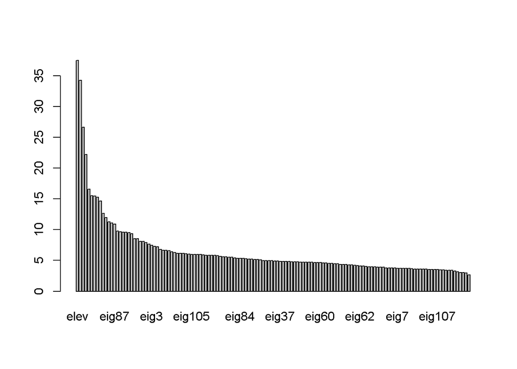

```r
mod.meigrf$variable.importance %>% sort(decreasing = T) %>% barplot
```